# Week 6 Muddiest Points Poisson Regression Part II

PUBHBIO 6250  
October 7, 2026  
Yuzi Zhang (zhang.15684@osu.edu)

This document reviews common points of confusion from **Week 6 - Poisson Regression Part II**, which is a reproduction of my responses discussed in the accompanying short video.

## Week 6 Muddiest Points

**Common muddiest points from Week 6:**

- Overdispersion
  - Poisson regression with robust variance
  - Negative binomial regression
- Change-in-estimates approach
- Interpretation
- Effect measure modification and confounding

### Muddy Point 1 – Overdispersion

- Overdispersion occurs when the outcome variance exceeds that predicted by the model: variance > mean
  - After “adjusting for” or “conditioning on” or “controlling for” covariates $X$, we still have variance > mean
  - $Var(Y)>E(Y|X)$
- Two main reasons for overdispersion [*see slide 6 of Lecture 5C*]
  - There are important predictors missing from the model (underfitting).
    - If we could include them in the model $\rightarrow$ solve the issue of overdispersion
  - The conditional distribution of $Y$ given $X$ is **NOT** Poisson
    - $Y|X$ has some other distribution that describes count data (not Poisson)

### Muddy Point 1 – Illustrative Example

**Simulated data**

### Muddy Point 1 – Example: Observed Counts

#### Let’s look at the first few rows of the simulated dataset

*(The dataset `dat_sim.dta` used in this example is available on Canvas)*:

```stata
use "dat_sim.dta", clear

list ID agegroup numvisits in 1/10
```

```
(Written by R.              )


     +--------------------------+
     | ID   agegroup   numvis~s |
     |--------------------------|
  1. |  1        <65          1 |
  2. |  2       >=65          3 |
  3. |  3        <65          0 |
  4. |  4       >=65          4 |
  5. |  5       >=65          0 |
     |--------------------------|
  6. |  6        <65          1 |
  7. |  7        <65          2 |
  8. |  8       >=65          1 |
  9. |  9        <65          0 |
 10. | 10        <65          1 |
     +--------------------------+
```

#### Let’s compute sample mean and variance of observed counts:

```stata
tabstat numvisits, stats(n mean var)
```

```
    Variable |         N      Mean  Variance
-------------+------------------------------
   numvisits |      5000     1.275  2.178211
--------------------------------------------
```

variance (2.18) > mean (1.28) $\rightarrow$ **Overdispersion!**

#### Let’s visulize the observed counts using a bar plot and add the expected counts from a Poisson distribution with the mean of 1.28 (the sample mean)

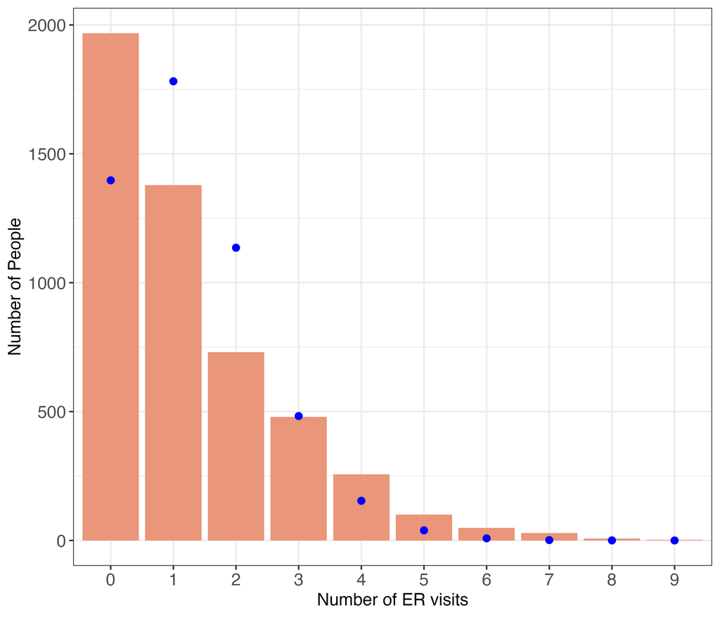

Bar plot of the observed counts with expected counts from a Poisson distribution

- Orange bar = # of people having 0, 1, …, 9 visits
- Blue dot = # of people we would expect to have 0, 1, …, 9 visits if we assume the count outcome follows a Poisson(1.28)
- The distribution of the observed counts is **NOT** Poisson if we ignore age, as indicated by the deviation of the blue dots from the height of the orange bars.

### Muddy Point 1 – Example: Fit an Intercept-Only NB Model

**How to test overdispersion?**

- Fit a negative binomial regression only including intercept (i.e., ignore age)
- Test for overdispersion: $H_0:\alpha=0$ vs. $H_1:\alpha\neq0$

```stata
nbreg numvisits, irr
```

```
Fitting Poisson model:

Iteration 0:  Log likelihood = -8155.4262
Iteration 1:  Log likelihood = -8155.4262

Fitting constant-only model:

Iteration 0:  Log likelihood = -7801.2412
Iteration 1:  Log likelihood = -7749.6666
Iteration 2:  Log likelihood = -7749.3391
Iteration 3:  Log likelihood = -7749.3389

Fitting full model:

Iteration 0:  Log likelihood = -7749.3389
Iteration 1:  Log likelihood = -7749.3389

Negative binomial regression                            Number of obs =  5,000
                                                        LR chi2(0)    =   0.00
Dispersion: mean                                        Prob > chi2   =      .
Log likelihood = -7749.3389                             Pseudo R2     = 0.0000

------------------------------------------------------------------------------
   numvisits |  Inc. rate   Std. err.      z    P>|z|     [95% conf. interval]
-------------+----------------------------------------------------------------
       _cons |      1.275   .0212722    14.56   0.000     1.233982    1.317382
-------------+----------------------------------------------------------------
    /lnalpha |  -.4984339   .0537237                     -.6037303   -.3931374
-------------+----------------------------------------------------------------
       alpha |   .6074813   .0326361                      .5467682     .674936
------------------------------------------------------------------------------
Note: Estimates are transformed only in the first equation to incidence rate.
LR test of alpha=0: chibar2(01) = 812.17               Prob >= chibar2 = 0.000
```

- $\exp(\hat{\beta}_0)$ = mean of $Y$ (1.28 from summary statistics)
- P-value < 0.05 $\rightarrow$ Reject $H_0:\alpha=0$, conclude that there is evidence of **overdispersion**!

### Muddy Point 1 – Example: Observed Counts by Age Group

#### Let’s compute sample mean and variance of observed counts **by age group**:

```stata
tabstat numvisits, stats(n mean var) by(agegroup)
```

```
Summary for variables: numvisits
Group variable: agegroup (agegroup)

agegroup |         N      Mean  Variance
---------+------------------------------
     <65 |      3011  .5088011  .5044906
    >=65 |      1989  2.434892  2.478279
---------+------------------------------
   Total |      5000     1.275  2.178211
----------------------------------------
```

Within age group, mean $\approx$ variance.

#### Within each age group, let’s visulize the observed counts using a bar plot and add the expected counts from a Poisson distribution with its sample mean

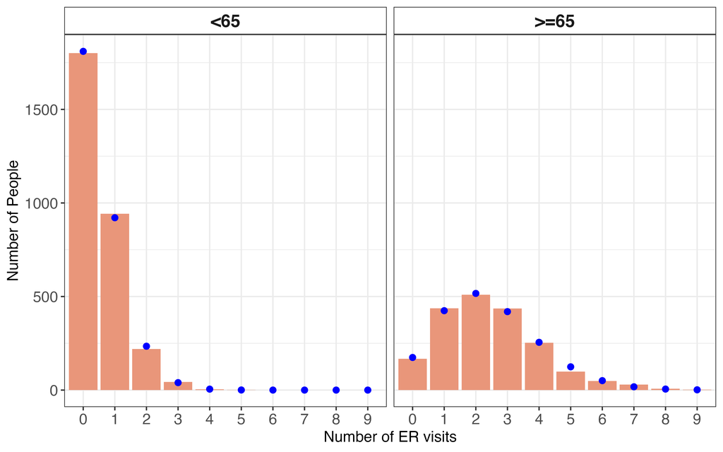

Bar plot of the observed counts with expected counts from a Poisson distribution by age group

The distribution of $Y$ conditional on age group **is** Poisson, as indicated by the alignment between the blue dots and heights of the orange bars.

### Muddy Point 1 – Example: Fit a NB Model with Age as Predictor

```stata
nbreg numvisits i.agegroup, irr
```

```
Fitting Poisson model:

Iteration 0:  Log likelihood = -6429.5811
Iteration 1:  Log likelihood = -6429.5806

Fitting constant-only model:

Iteration 0:  Log likelihood = -7801.2412
Iteration 1:  Log likelihood = -7749.6666
Iteration 2:  Log likelihood = -7749.3391
Iteration 3:  Log likelihood = -7749.3389

Fitting full model:

Iteration 0:  Log likelihood = -6901.2369
Iteration 1:  Log likelihood = -6650.7099
Iteration 2:  Log likelihood =  -6479.705
Iteration 3:  Log likelihood = -6429.6801
Iteration 4:  Log likelihood = -6429.4912
Iteration 5:  Log likelihood =  -6429.487
Iteration 6:  Log likelihood =  -6429.487

Negative binomial regression                           Number of obs =   5,000
                                                       LR chi2(1)    = 2639.70
Dispersion: mean                                       Prob > chi2   =  0.0000
Log likelihood = -6429.487                             Pseudo R2     =  0.1703

------------------------------------------------------------------------------
   numvisits |        IRR   Std. err.      z    P>|z|     [95% conf. interval]
-------------+----------------------------------------------------------------
    agegroup |
       >=65  |   4.785548   .1406427    53.27   0.000     4.517682    5.069296
       _cons |   .5088011    .013017   -26.41   0.000     .4839172    .5349645
-------------+----------------------------------------------------------------
    /lnalpha |  -5.225247   2.334003                     -9.799808   -.6506856
-------------+----------------------------------------------------------------
       alpha |    .005379   .0125547                      .0000555     .521688
------------------------------------------------------------------------------
Note: Estimates are transformed only in the first equation to incidence-rate
      ratios.
Note: _cons estimates baseline incidence rate.
LR test of alpha=0: chibar2(01) = 0.19                 Prob >= chibar2 = 0.333
```

After including the variable `agegroup` into the NB model, we have p-value = 0.333 > 0.05 $\rightarrow$ Fail to reject $H_0:\alpha=0$, conclude that there is **NO** evidence of overdispersion!

### Muddy Point 1 – Example: Fit a Poisson Model with Age as Predictor

```stata
glm numvisits i.agegroup, family(poisson) link(log) eform
```

```
Iteration 0:  Log likelihood = -6505.2183
Iteration 1:  Log likelihood = -6429.7149
Iteration 2:  Log likelihood = -6429.5806
Iteration 3:  Log likelihood = -6429.5806

Generalized linear models                         Number of obs   =      5,000
Optimization     : ML                             Residual df     =      4,998
                                                  Scale parameter =          1
Deviance         =  5247.397154                   (1/df) Deviance =   1.049899
Pearson          =   5007.92391                   (1/df) Pearson  =   1.001986

Variance function: V(u) = u                       [Poisson]
Link function    : g(u) = ln(u)                   [Log]

                                                  AIC             =   2.572632
Log likelihood   = -6429.580563                   BIC             =  -37321.53

------------------------------------------------------------------------------
             |                 OIM
   numvisits |        IRR   std. err.      z    P>|z|     [95% conf. interval]
-------------+----------------------------------------------------------------
    agegroup |
       >=65  |   4.785548   .1402766    53.41   0.000      4.51836    5.068536
       _cons |   .5088011   .0129993   -26.45   0.000     .4839504    .5349278
------------------------------------------------------------------------------
Note: _cons estimates baseline incidence rate.
```

- Estimates of the intercept and the coefficient of age are very similar to the estimates from the NB model with age group as the predictor.
- **This Poisson regression model is expected to fit the observed data!**

### Muddy Point 1 – Overdispersion

- Adding extra predictors doesn’t always fix the overdispersion issue.
- Why?
  - The underlying distribution for the data is not a Poisson
  - There are still missing covariates that are necessary for the conditional Poisson distribution (e.g., $Y\,|\,$age, insurance type $\sim$ Poisson, but we don’t have a covariate for insurance type)
- What can we do? – Remedies mentioned in this course
  - Poisson regression + robust variance
  - Negative-binomial regression
  - Zero-inflated and zero-truncated Poisson regression (presented for your information; if you are interested in learning more about them, a great textbook is: Hardin, J. W., & Hilbe, J. M. (2007). *Generalized Linear Models and Extensions*. Stata Press.)

### Muddy Point 1 – Poisson Regression with Robust Variance

Poisson regression with robust variance is appropriate when:

- The conditional mean of $Y$ given $X$ is correctly specified.
  - $E(Y|X) = \exp(\beta_0+\beta_1x_1+\dots+\beta_px_p)$
  - $Var(Y|X)$ is not the same as $E(Y|X)$.
- Estimates of regression coefficients (i.e., estimates of $\beta$s) are the same as regular Poisson regression.
- Estimates of SE of estimated regression coefficients are different from regular Poisson regression.
- The interpretation of $\beta$s is exactly the same as regular Poisson regression.

### Muddy Point 1 – Negative-Binomial Regression

- Often a better solution to overdispersion compared to the robust variance estimator
- A more general model including an extra parameter $\alpha$
  $$\log(E(Y|\boldsymbol{x})) = \beta_0 + \beta_1 x_1 + \dots + \beta_p x_p$$
- The interpretation of regression coefficients in NB regression is the same as in Poisson regression!

**Robust variance vs. NB regression**

- NB regression is often a better choice than Poisson regression with the robust variance estimator, since it is more general and introduces an extra parameter allowing for testing for overdispersion (as we did in Lab and the illustrative example)
- Robust variance is straightforward to implement

### Muddy Point 1 – Should We Always Implement Remedies Just in Case?

- Loss of efficiency when the Poisson regression is correct.
  - Both approaches will overestimate standard errors of the estimated regression coefficient $\rightarrow$ reduce statistical power of conducting hypothesis tests.

### Muddy Point 1 – Summary

**General procedure of handling overdispersion in Poisson regression**

- Check data to see if there is overdispersion: sample variance > sample mean
- Consider some common causes
  - Missing important covariates in the model
  - The underlying distribution is not Poisson
  - Too many zeros
- Choose alternatives accordingly
  - Adding more covariates
  - Poisson regression + robust variance
    - $E(Y|X)$ is correctly specified by the model, but $Var(Y|X) \neq E(Y|X)$
  - Negative binomial regression ($\alpha$ and its hypothesis test)
  - Zero-truncated and zero-inflated Poisson regression

### Muddy Point 2 – Change-in-Estimates Approach

$$\text{Percent change} = \left| \frac{M_{unadj} - M_{adj}}{M_{adj}} \right|$$

- Note that there is an absolute-value sign in the formula (i.e., a pair of vertical bars).
- The order of these two quantities does not matter in the numerator.

$$\text{Percent change} = \left| \frac{M_{unadj} - M_{adj}}{M_{adj}} \right| = \left| \frac{M_{adj} - M_{unadj}}{M_{adj}} \right|$$

### Muddy Point 3 – Interpretation

- The video responding to muddy points from Week 5 – Poisson Regression Part I:
  - For multiple Poisson regression models, remember the extra piece “controlling for other covariates”/“adjusting for other covariates”/“holding other covariates constant”
  - The interpretation for Poisson regression with robust variance and negative binomial regression is the same as regular Poisson regression.

### Muddy Point 4 – Effect Measure Modification and Confounding

**Effect measure modification** occurs when a measure of association between an exposure ($X$) and an outcome ($Y$) depends on the value of a third variable ($Z$).

**Confounding** occurs when an exposure ($X$) and an outcome ($Y$) have an underlying common cause ($C$).

- Confounding and effect measure modification are completely separate! Neither implies the other.
- These two definitions are invariant across different regression models.
  - e.g., Deliverable 3 in Data Analysis 1 provides a great example of looking at effect modification. Although it is in the context of logistic regression, the underlying logic remains the same for Poisson regression.

## Recap

1. **Overdispersion**: variance exceeds the mean predicted by the Poisson model; common causes: important predictors are missing; $Y|X$ is not really a Poisson.
2. **Checking for it**: fit an negative binomial model and test $H_0:\alpha=0$; a significant testing result indicates overdispersion.
3. **Remedies**: Poisson regression with robust variance, or negative binomial regression. Both approaches leave the interpretation of $\beta$s unchanged from standard Poisson regression. NB regression is usually preferred since it also gives a formal test for overdispersion by testing for $H_0:\alpha =0$.
4. **Don’t over-apply remedies**: if the Poisson model is actually correct, robust variance or NB regression will overestimate standard errors and reduce statistical power.
5. **Change-in-estimates**: the formula uses absolute value, so the order of the two estimates being compared in the numerator doesn’t matter.
6. **Confounding vs. effect measure modification**: The two are unrelated concepts, one does not imply or rule out the other, and both definitions apply the same way regardless of which regression model (logistic, Poisson, etc.) you’re using.